# Clustering and enrichment analysis

Lukas Häuser

2024/05/15

```r
suppressPackageStartupMessages({
  library(GenomicRanges)
  library(epiwraps)
  library(ggplot2)
  library(rGREAT)
})

set.seed(0) # fix seed to ensure reproducibility
```

## Download the data

```r
options(timeout = 6000)
download.file("https://ethz-ins.org/content/w10.assignment.zip", "w10.assignment.zip")
unzip("w10.assignment.zip")
list.files()
```

## Prepare the regions and the tracks

```r
N <- 3
tracks.files <- list.files(pattern="bw$")
peaks.files <- list.files(pattern="bed$")
```

```r
peaks <- sapply(X=peaks.files, FUN=rtracklayer::import.bed)
peaks <- lapply(peaks, FUN=function(x) x[x$score>990]) # filter for high quality peaks
regions <- reduce(unlist(GRangesList(peaks)))
```

```r
ese <- signal2Matrix(tracks.files, regions, extend=2000)
```

```
## Reading Creb1.bw
```

```
## Reading Creb3.bw
```

```
## Reading Creb3L1.bw
```

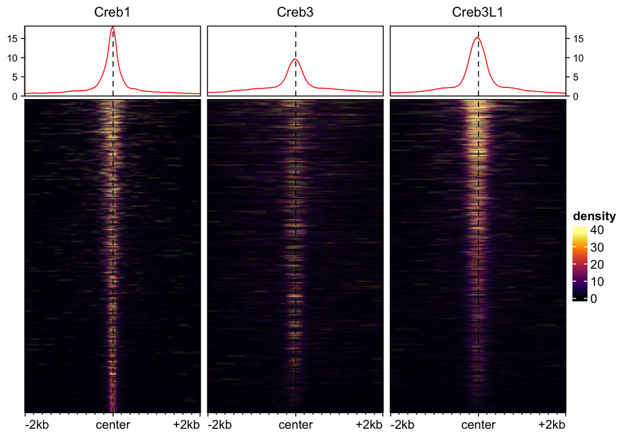

```r
plotEnrichedHeatmaps(ese, cluster_rows = FALSE, show_row_dend=TRUE)
```

## Clustering

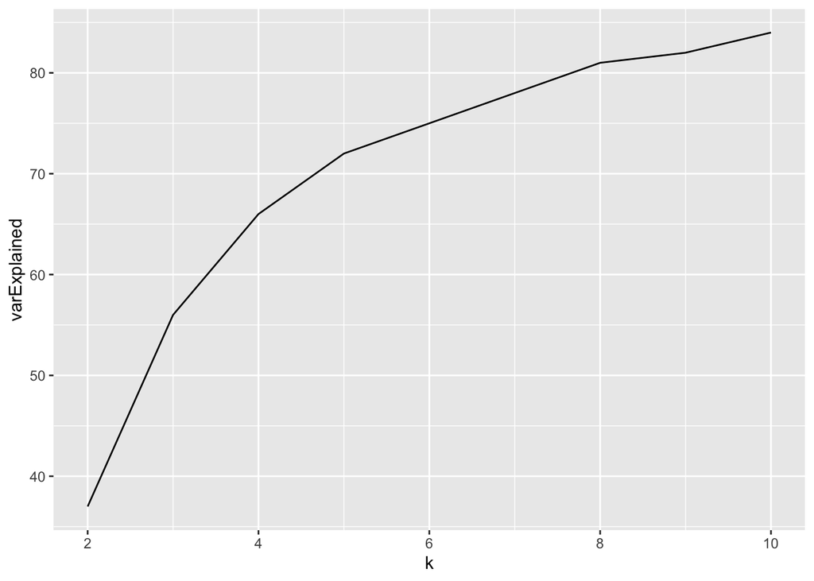

```r
cl <- clusterSignalMatrices(ese, k=2:10)
print(ggplot(cl$varExplained, aes(k, varExplained)) + geom_line())
```

The elbow plot are rather inconclusive. However, the elbow plot has a little kink at `k=8`, so we took `k=8`.

```r
mycolors <- c("1"="red", "2"="blue", "3"="darkgreen", "4"="orange", "5"="pink", "6"="violet", "7"="brown", "8"="grey")
cl <- clusterSignalMatrices(ese, k=8)
```

```
##   ~81% of the variance explained by clusters
```

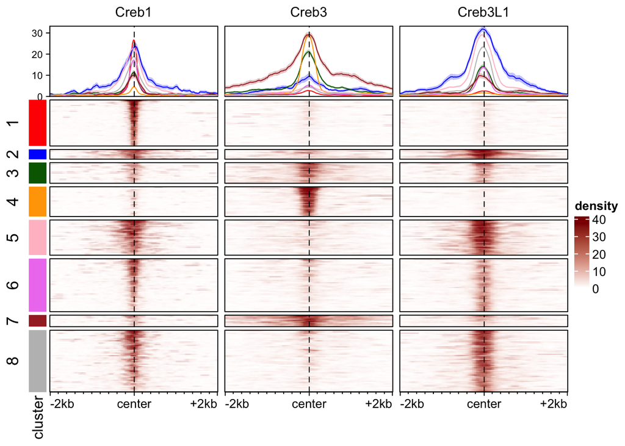

```r
rowData(ese)$cluster <- cl
print(plotEnrichedHeatmaps(ese, row_split="cluster", mean_color=mycolors, colors=c("white","darkred")))
```

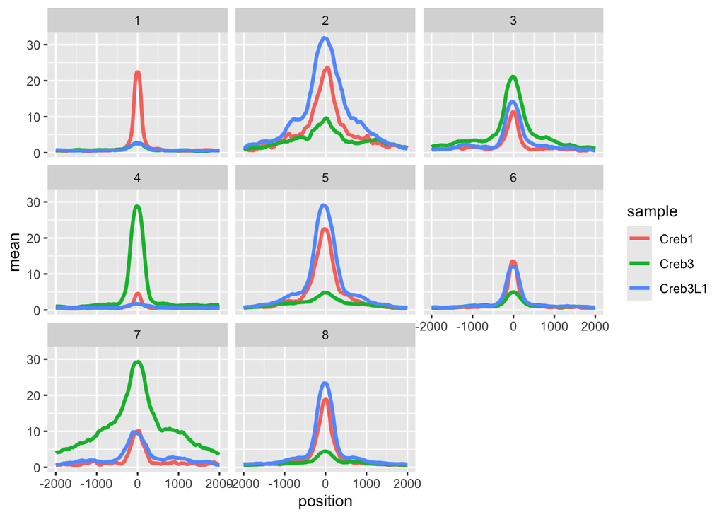

```r
d <- meltSignals(ese, splitBy=cl)
plot(ggplot(d, aes(position, mean, colour=sample)) + geom_line(size=1.2) + facet_wrap(~split))
```

## Enrichment analysis

Enrichment analysis with rGREAT, which is based on GO.

Find what’s enriched in the first cluster with respect to the others:

```r
split.regions <- split(rowRanges(ese), rowData(ese)$cluster)
res <- great(split.regions[["1"]], gene_sets="GO:BP", tss_source="hg38", background=regions, cores=6)
```

[output not shown]

[output not shown]

[output not shown]

[output not shown]

[output not shown]

[output not shown]

[output not shown]

[output not shown]

[output not shown]

[output not shown]

[output not shown]

[output not shown]

[output not shown]

[output not shown]

[output not shown]

```
## * in total 315 `gr`.
```

[output not shown]

[output not shown]

[output not shown]

```
## * in total 2405 gene sets.
```

[output not shown]

[output not shown]

```r
bp <- getEnrichmentTables(res)
head(bp)
```

```
##           id                        description genome_fraction
## 1 GO:0009653 anatomical structure morphogenesis      0.25400306
## 2 GO:2000145        regulation of cell motility      0.09230533
## 3 GO:0016477                     cell migration      0.15028949
## 4 GO:0048699              generation of neurons      0.13090072
## 5 GO:0030182             neuron differentiation      0.12587047
## 6 GO:0008283      cell population proliferation      0.26930335
##   observed_region_hits fold_enrichment      p_value    p_adjust mean_tss_dist
## 1                  117        1.462300 2.781398e-06 0.001055721        122336
## 2                   55        1.891583 3.540810e-06 0.001055721        109006
## 3                   78        1.647614 4.395580e-06 0.001055721        114183
## 4                   70        1.697639 5.833273e-06 0.001055721        122648
## 5                   68        1.715041 5.869416e-06 0.001055721        123583
## 6                  121        1.426373 6.006896e-06 0.001055721        112977
##   observed_gene_hits gene_set_size fold_enrichment_hyper p_value_hyper
## 1                 89           195              1.424755  1.088990e-05
## 2                 38            64              1.853482  3.487998e-06
## 3                 57           109              1.632425  3.614397e-06
## 4                 49           108              1.416306  1.691568e-03
## 5                 47           103              1.424444  1.820893e-03
## 6                 94           223              1.315854  3.035211e-04
##   p_adjust_hyper
## 1   0.0015213185
## 2   0.0006311641
## 3   0.0006311641
## 4   0.0560908640
## 5   0.0565286026
## 6   0.0163084248
```

Which of these gene sets are significant and how large is their log fold enrichment?

```r
bp.significant <- bp[bp$p_adjust < 0.05,]
print(dim(bp.significant))
```

```
## [1] 60 13
```

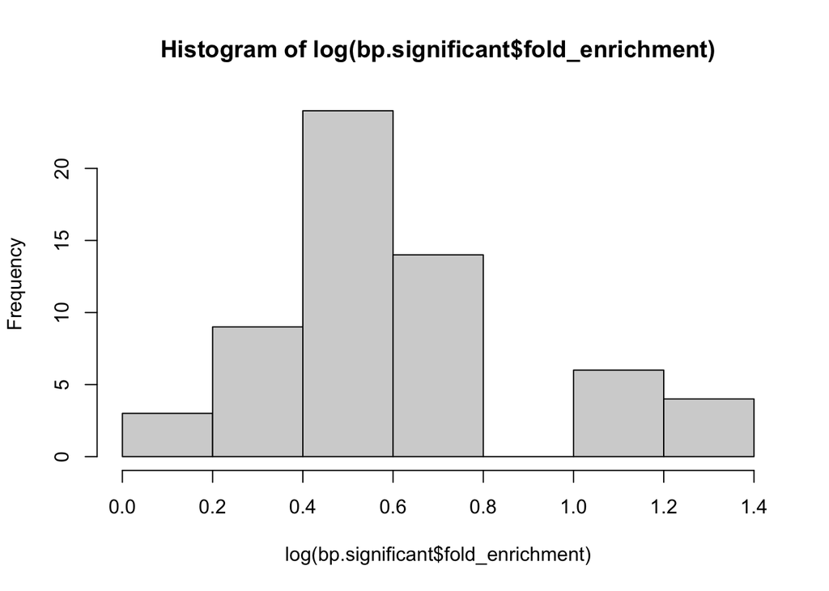

```r
hist(log(bp.significant$fold_enrichment))
```

## Results

Creb1 and Creb3L1 show quite similar peaks in most clusters. However, in cluster 1 Creb1 shows a strong peak, while Creb3L1 does not. Thus, we can use cluster 1 to differentiate between Creb1 and Creb3L1. In contrast, Creb3 gives very different signals compared to Creb1 and Creb3L1 for most clusters. It can most clearly be differentiated from Creb1 and Creb3L1 in by looking at cluster 4.

In the enrichment analysis, we found 60 significantly enriched gene sets. Their log fold enrichments are all positive and go up to 1.4, while most are between 0.2 and 0.8.